# Data Science Capstone

Raj Prasad  
December 2016

### Why Build a Next-Word Predictor?

[figure not shown]

- Typing is slow on small touch screens
- Typing is error prone on such devices
- Wouldn't it be great if the device could predict the word you need and pop it in with a single click?

### Example App

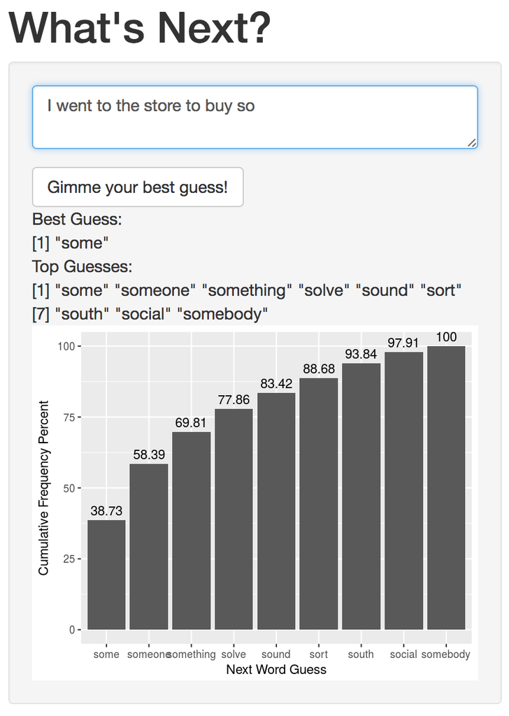

### The Model

- The code for the model build is available [here](https://github.com/daddyprasad5/capstone_final).
- It is an absolute discount, back-off, trigram language model.
- It is a “trigram language model” because it assigns probability to 3-word sequences given a training corpus.
- It is a “back-off” model because it falls back (or backs off) to lower order (bigram, unigram) models after looking for trigram matches.
- It is an “absolute discount” model because it redistributes a set probability weight from higher- to lower-order n-gram guesses.

### Accuracy & Performance

Perplexity: 206

Accuracy with…

- 1 guess: 15%
- 3 guesses: 24%
- 10 guesses: 38%

Best guess accuracy after typing…

- 1 letter: 37%
- 2 letters: 47%
- 3 letters: 53%

Performance  
Time to inital guess*: 60.6 ms

[figure not shown]

*[performance report](http://daddyprasad5.github.io/perfGetDistro.html)  
**network and ui factors will increase perceived latency

### Roadmap

I'm exploring these improvements:

- Improve performance of the model build using the [parallel package](https://stat.ethz.ch/R-manual/R-devel/library/parallel/doc/parallel.pdf)
- Improve accuracy using topic modeling with the [topicmodels package](https://cran.r-project.org/web/packages/topicmodels/vignettes/topicmodels.pdf)
- Improve accuracy by weighting guesses that produce more likely part-of-speech sequences, using the [OpenNLP package](https://cran.r-project.org/web/packages/openNLP/openNLP.pdf)